# R example 2: regression analysis for randomized experiment

- **Background**:

  A school district aims to assess the effectiveness of a new teaching method designed to improve students’ mathematics performance. They conduct a completely randomized experiment involving 200 high school students, all in the same grade level. Each student is randomly assigned to one of two groups:
  - Treatment Group: Students who receive instruction using the new teaching method.
  - Control Group: Students who continue with the standard teaching method.
- **Data Collected**:
  - Treatment Indicator: A binary variable where 1 indicates the student received the new teaching method, and 0 indicates the standard method.
  - Prior Achievement Level: A categorical variable indicating the prior math achievement level (Basic, Proficient, Advanced) of each student.
  - Post-Test Scores (outcome): End-of-term math test scores for each student.

We used asynthetic dataset generated by R:

```r
set.seed(123)

# Number of students
n <- 200

# Generate Prior Achievement Levels
Achievement_levels <- c("Basic", "Proficient", "Advanced")
Achievement <- sample(Achievement_levels, n, replace = TRUE, prob = c(0.3, 0.5, 0.2))

# Convert Achievement to factor with specified order
Achievement <- factor(Achievement, levels = c("Basic", "Proficient", "Advanced"))

# Randomly assign students to Treatment (1) or Control (0) groups
Treatment <- rbinom(n, 1, 0.5)



# Generate random error term (assuming normal distribution)
epsilon <- rnorm(n, mean = 0, sd = 5)

# Calculate potential post-test scores without the treatment
PostTest_0 <- 60 + ifelse(Achievement == "Proficient", 10, 0) +
            ifelse(Achievement == "Advanced", 20, 0) +
            epsilon

## individual treatment effect, allowing heterogeneity across individuals and interaction with the achievement levels
Treatment_effect <- 5 + ifelse(Achievement == "Proficient", 10, 0) + ifelse(Achievement == "Advanced", -2, 0) +  rnorm(n, mean = 0, sd = 5)

## observed outcome: Y = Y(0) + \tau_i W_i
PostTest <- PostTest_0 + Treatment_effect * Treatment

# Create a data frame for the observed data
data <- data.frame(
  Y = PostTest,
  W = Treatment,
  X = Achievement
)

print(paste("True average treatment effect:", round(mean(Treatment_effect), digits=2)))
```

```
## [1] "True average treatment effect: 9.94"
```

- Visualize the data

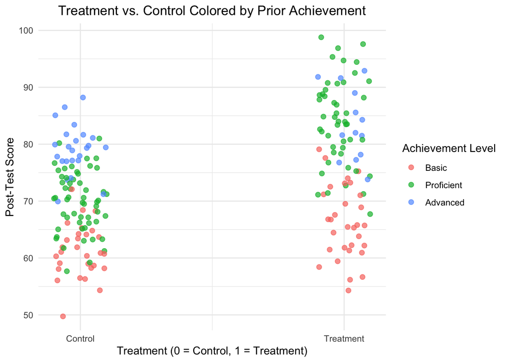

```r
## Visualize the data
data$Treatment_jitter <- jitter(data$W, amount = 0.1)

# Load ggplot2 for plotting
library(ggplot2)

# Create the scatter plot
ggplot(data, aes(x = Treatment_jitter, y = Y, color = X)) +
  geom_point(alpha = 0.7, size = 2) +
  labs(
    title = "Treatment vs. Control Colored by Prior Achievement",
    x = "Treatment (0 = Control, 1 = Treatment)",
    y = "Post-Test Score",
    color = "Achievement Level"
  ) +
  theme_minimal() +
  scale_x_continuous(breaks = c(0, 1), labels = c("Control", "Treatment")) +
  theme(
    legend.position = "right",
    plot.title = element_text(hjust = 0.5)
  )
```

## 1. regression with no covariates adjustment

- First, we perform regression with no covariates adjustment and get the estimates and standard errors for the average treatment effect with or without the homoscedastic error assumption

```r
lm.result1 <- lm(Y ~ W, data = data)
## with the homoscedastic error assumption
sd <- summary(lm.result1)$coefficients["W", "Std. Error"]
est <- summary(lm.result1)$coefficients["W", "Estimate"]

## without the homoscedastic error assumption
library(sandwich)

## with the HC2 adjustment
sd2 <- sqrt(vcovHC(lm.result1, type = "HC2")[2, 2])
result1 <- c(est, sd, sd2)
names(result1) <- c("estimate", "Homoscedastic error", "Sandwich with HC2")
print(result1)
```

```
##            estimate Homoscedastic error   Sandwich with HC2
##            8.325908            1.339229            1.373047
```

## 2. Regression with covariate adjustment

We incorporate pre-treatment achievement level in the linear regression and still target the average treatment effect.

- Linear regression without interactions
  - X is a factor with 3 levels

```r
## If we assume the conditional average treatment effect of the new drug to be the same across the pre-treatment glucose levels
lm.result2 <- lm(Y ~ W + X, data = data)
summary(lm.result2)
```

```
##
## Call:
## lm(formula = Y ~ W + X, data = data)
##
## Residuals:
##      Min       1Q   Median       3Q      Max
## -14.3390  -4.6270   0.1561   4.2207  17.1226
##
## Coefficients:
##             Estimate Std. Error t value Pr(>|t|)
## (Intercept)  58.7926     0.9510   61.82   <2e-16 ***
## W             9.6559     0.9132   10.57   <2e-16 ***
## XProficient  13.2170     1.0397   12.71   <2e-16 ***
## XAdvanced    18.4742     1.3454   13.73   <2e-16 ***
## ---
## Signif. codes:  0 '***' 0.001 '**' 0.01 '*' 0.05 '.' 0.1 ' ' 1
##
## Residual standard error: 6.396 on 196 degrees of freedom
## Multiple R-squared:  0.6198, Adjusted R-squared:  0.614
## F-statistic: 106.5 on 3 and 196 DF,  p-value: < 2.2e-16
```

```r
## with the homoscedastic error assumption
sd <- summary(lm.result2)$coefficients["W", "Std. Error"]
est <- summary(lm.result2)$coefficients["W", "Estimate"]

## without the homoscedastic error assumption
## with the HC2 adjustment
sd2 <- sqrt(vcovHC(lm.result2, type = "HC2")[2, 2])
result2 <- c(est, sd, sd2)
names(result2) <- c("estimate", "Homoscedastic error", "Sandwich with HC2")
print(result2)
```

```
##            estimate Homoscedastic error   Sandwich with HC2
##           9.6558557           0.9132314           0.9403229
```

We see that add pre-treatment covariates can indeed increase our estimation accuracy.

- Linear regression with interactions
  - We need to center $X$ first to guarantee that the coefficient of $W$ is the average treatment effect, but $X$ is a factor, so we need to convert it into group indicators

```r
data$X1 <- data$X == "Proficient"
data$X2 <- data$X == "Advanced"
data$X1 <- data$X1 - mean(data$X1)
data$X2 <- data$X2 - mean(data$X2)
lm.result3 <- lm(Y ~ W + X1 + X2 + W:X1 + W:X2, data = data)
summary(lm.result3)
```

```
##
## Call:
## lm(formula = Y ~ W + X1 + X2 + W:X1 + W:X2, data = data)
##
## Residuals:
##      Min       1Q   Median       3Q      Max
## -16.3155  -3.8493  -0.1029   4.1444  14.7565
##
## Coefficients:
##             Estimate Std. Error t value Pr(>|t|)
## (Intercept)  69.0132     0.5793 119.131  < 2e-16 ***
## W             9.5801     0.8559  11.193  < 2e-16 ***
## X1            8.7434     1.3747   6.360 1.42e-09 ***
## X2           17.8872     1.6531  10.821  < 2e-16 ***
## W:X1          9.0929     1.9481   4.668 5.68e-06 ***
## W:X2         -0.5227     2.5789  -0.203     0.84
## ---
## Signif. codes:  0 '***' 0.001 '**' 0.01 '*' 0.05 '.' 0.1 ' ' 1
##
## Residual standard error: 5.99 on 194 degrees of freedom
## Multiple R-squared:  0.6698, Adjusted R-squared:  0.6613
## F-statistic: 78.72 on 5 and 194 DF,  p-value: < 2.2e-16
```

```r
## with the homoscedastic error assumption
sd <- summary(lm.result3)$coefficients["W", "Std. Error"]
est <- summary(lm.result3)$coefficients["W", "Estimate"]

## without the homoscedastic error assumption
## with the HC2 adjustment
sd2 <- sqrt(vcovHC(lm.result3, type = "HC2")[2, 2])
result3 <- c(est, sd, sd2)
names(result3) <- c("estimate", "Homoscedastic error", "Sandwich with HC2")
print(result3)
```

```
##            estimate Homoscedastic error   Sandwich with HC2
##           9.5800660           0.8558842           0.8781174
```

- Given the estimates and standard deviations, we can compute the p-value and CI assuming that the estimate follows a normal distribution.

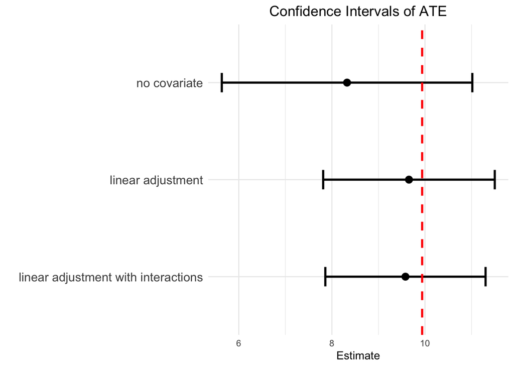

```r
result <- data.frame(rbind(result1, result2, result3))
result$label <- factor(c("no covariate", "linear adjustment", "linear adjustment with interactions"),
                       levels = c("linear adjustment with interactions", "linear adjustment", "no covariate"))
# Confidence interval level
alpha <- 0.05
z <- qnorm(1 - alpha / 2)

# Calculate confidence intervals
result$CI_Lower <- result[, 1] - z * result[, 3]
result$CI_Upper <- result[, 1] + z * result[, 3]

true_value <- mean(Treatment_effect)  # You can set this to the actual true value

# Create the plot
ggplot(result, aes(y = label, x = estimate)) +
  geom_point(size = 3) +  # Add points for estimates
  geom_errorbarh(aes(xmin = CI_Lower, xmax = CI_Upper), height = 0.2, size = 1) +  # Horizontal error bars for CIs
  geom_vline(xintercept = true_value, color = "red", linetype = "dashed", size = 1) +  # Add red vertical line for true value
  labs(title = "Confidence Intervals of ATE", x = "Estimate", y = "") +
  theme_minimal() +  # Use a clean theme
  theme(axis.text.y = element_text(size = 12),  # Customize text size for labels
        plot.title = element_text(hjust = 0.5, size = 14))  # Center the title
```